# Case Study 1: Indoor Positioning System

Pankaj Kumar, Brady Arendale, Kay Ayala

5/14/2020

# Introduction

We want to know if it is possible to accurately determine position on the floor of a building using a mobile device to measure signal strength from various access points. Researchers at the University of Mannheim created a dataset for this purpose. The dataset was created by standing at certain locations, holding a device at certain orientations, and repeatedly measuring signal strength to several access points. The floor plan is shown below [1]:

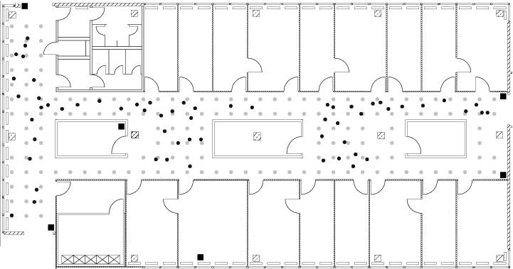

Floor layout

There are a total of 166 locations, spaced one meter apart. The researchers held the device at 8 different orientations, in increments of 45 degrees. For each combination of location and orientation, the researchers recorded 110 measurements to each of 6 access points.

# Data Preparation

In order to start training models to predict location of a device, first we needed to get our data into a usable form. We first read the entire `offline.final.trace.txt` file into a character variable called `txt`.

```r
source("case_study_functions.R", echo = T, prompt.echo = "", spaced = F)
```

```
## library(tidyverse)
```

```
## library(magrittr)
```

```
## library(fields)
```

[output not shown]

[output not shown]

[output not shown]

```r
txt = readLines("data/offline.final.trace.txt")
length(txt)
```

```
## [1] 151392
```

We have 151392 total lines in our `txt` variable. The first few lines look like this:

```r
txt[1:4]
```

```
## [1] "# timestamp=2006-02-11 08:31:58"
## [2] "# usec=250"
## [3] "# minReadings=110"
## [4] "t=1139643118358;id=00:02:2D:21:0F:33;pos=0.0,0.0,0.0;degree=0.0;00:14:bf:b1:97:8a=-38,2437000000,3;00:14:bf:b1:97:90=-56,2427000000,3;00:0f:a3:39:e1:c0=-53,2462000000,3;00:14:bf:b1:97:8d=-65,2442000000,3;00:14:bf:b1:97:81=-65,2422000000,3;00:14:bf:3b:c7:c6=-66,2432000000,3;00:0f:a3:39:dd:cd=…
```

We now see that there are lines beginning in # that do not contain actual data, so we will discard them. Additionally, each record is all on one line in a format that we will have to parse. We split each line at the euqal signs, semicolons, and commas and picked out the data by position. Since each line contained information about the device as well as the access points, we opted to store each device-access point combination as its own line. To do this, we replicated the device information (time, MAC address, position) and appended it to the information about each access point.

#### Explore orientation

```r
lines = txt[ substr(txt, 1, 1) != "#" ]
tmp = lapply(lines, processLine)
offline = as.data.frame(do.call("rbind", tmp),stringsAsFactors = FALSE)
names(offline) = c("time", "scanMac", "posX", "posY", "posZ",
                   "orientation", "mac", "signal",
                   "channel", "type")
numVars = c("time", "posX", "posY", "posZ",
            "orientation", "signal")


offline[ numVars ] = lapply(offline[ numVars ], as.numeric)

offline = offline[ offline$type == "3", ]
offline = offline[ , "type" != names(offline) ]
dim(offline)
```

```
## [1] 978443      9
```

```r
offline$rawTime = offline$time
offline$time = offline$time/1000
class(offline$time) = c("POSIXt", "POSIXct")
offline = offline[ , !(names(offline) %in% c("scanMac", "posZ"))]

length(unique(offline$orientation))
```

```
## [1] 203
```

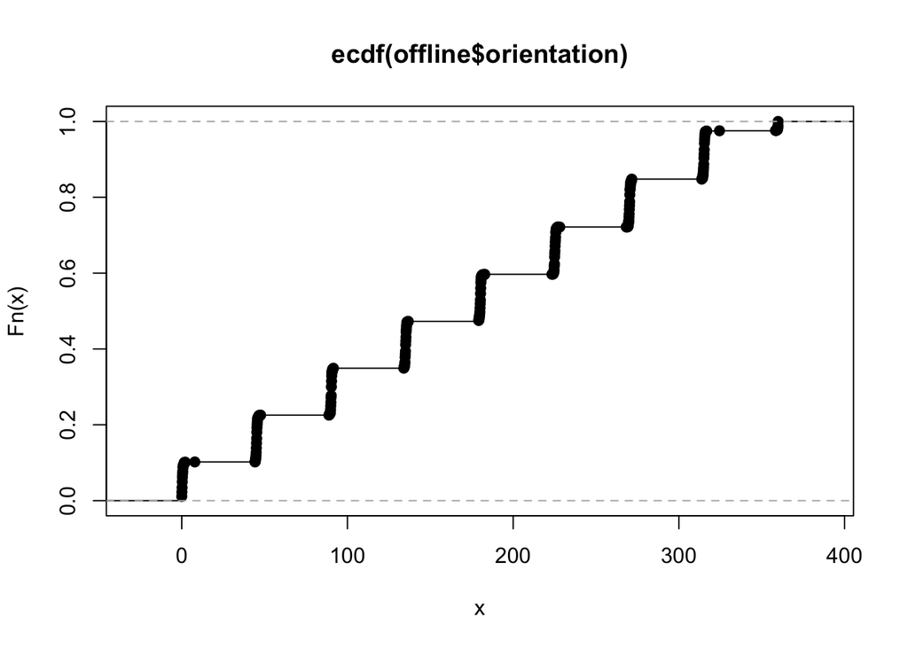

```r
## [1] 203
plot(ecdf(offline$orientation))
```

#### Fix orientation

We ll use following code to slab orientations in 8 discrete values

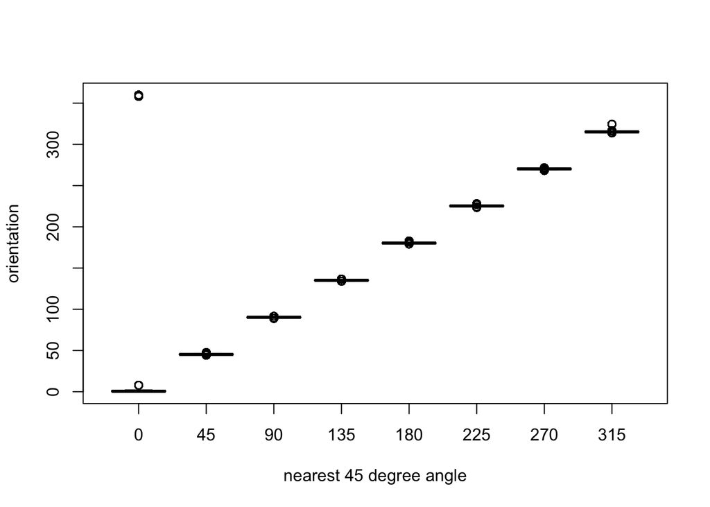

```r
offline$angle = roundOrientation(offline$orientation)

with(offline, boxplot(orientation ~ angle,
                      xlab = "nearest 45 degree angle",
                      ylab="orientation"))
```

```r
c(length(unique(offline$mac)), length(unique(offline$channel)))
```

```
## [1] 12  8
```

#### Explore location count

```r
tokens = strsplit(txt[4], "[;=,]")[[1]]

tokens[1:10]
```

```
##  [1] "t"                 "1139643118358"     "id"
##  [4] "00:02:2D:21:0F:33" "pos"               "0.0"
##  [7] "0.0"               "0.0"               "degree"
## [10] "0.0"
```

```r
tokens[c(2, 4, 6:8, 10)]
```

```
## [1] "1139643118358"     "00:02:2D:21:0F:33" "0.0"
## [4] "0.0"               "0.0"               "0.0"
```

```r
tmp = matrix(tokens[ - (1:10) ], ncol = 4, byrow = TRUE)
mat = cbind(matrix(tokens[c(2, 4, 6:8, 10)], nrow = nrow(tmp),
                   ncol = 6, byrow = TRUE),
            tmp)
```

#### Exploring macs

```r
table(offline$mac)
```

```
##
## 00:04:0e:5c:23:fc 00:0f:a3:39:dd:cd 00:0f:a3:39:e0:4b 00:0f:a3:39:e1:c0
##               418            145619             43508            145862
## 00:0f:a3:39:e2:10 00:14:bf:3b:c7:c6 00:14:bf:b1:97:81 00:14:bf:b1:97:8a
##             19162            126529            120339            132962
## 00:14:bf:b1:97:8d 00:14:bf:b1:97:90 00:30:bd:f8:7f:c5 00:e0:63:82:8b:a9
##            121325            122315               301               103
```

```r
subMacs = names(sort(table(offline$mac), decreasing = TRUE))[1:7]
offline = offline[ offline$mac %in% subMacs, ]
```

#### Explore Channels

```r
macChannel = with(offline, table(mac, channel))
apply(macChannel, 1, function(x) sum(x > 0))
```

```
## 00:0f:a3:39:dd:cd 00:0f:a3:39:e1:c0 00:14:bf:3b:c7:c6 00:14:bf:b1:97:81
##                 1                 1                 1                 1
## 00:14:bf:b1:97:8a 00:14:bf:b1:97:8d 00:14:bf:b1:97:90
##                 1                 1                 1
```

We can drop channels since they don’t provide any additional information and there is one to one relation between mac and channel

```r
offline = offline[ , "channel" != names(offline)]
```

#### Exploring location count

```r
locDF = with(offline,
             by(offline, list(posX, posY), function(x) x))
length(locDF)
```

```
## [1] 476
```

```r
sum(sapply(locDF, is.null))
```

```
## [1] 310
```

```r
locDF = locDF[ !sapply(locDF, is.null) ]

length(locDF)
```

```
## [1] 166
```

```r
locCounts = sapply(locDF, nrow)

locCounts = sapply(locDF,
                   function(df)
                     c(df[1, c("posX", "posY")], count = nrow(df)))


class(locCounts)
```

```
## [1] "matrix"
```

```r
 dim(locCounts)
```

```
## [1]   3 166
```

```r
 locCounts[ , 1:8]
```

```
##       [,1] [,2] [,3] [,4] [,5] [,6] [,7] [,8]
## posX  0    1    2    0    1    2    0    1
## posY  0    0    0    1    1    1    2    2
## count 5505 5505 5506 5524 5543 5558 5503 5564
```

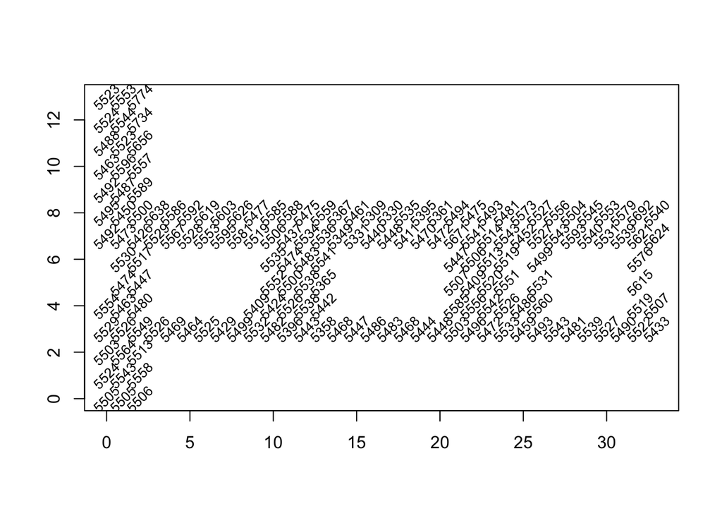

```r
 locCounts = t(locCounts)
 plot(locCounts, type = "n", xlab = "", ylab = "")



 text(locCounts, labels = locCounts[,3], cex = .8, srt = 45)
```

#### Read processed data

We define function readData using above findings to collect offline data and we create two filtered datasets by excluding one mac from each that are at same location

```r
offline_file_path = "data/offline.final.trace.txt"
online_file_path = "data/online.final.trace.txt"

offline = readData(offline_file_path)

offline$posXY = paste(offline$posX, offline$posY, sep = "-")

 offlineSummary = createSummary(offline)

  subMacs = names(sort(table(offline$mac), decreasing = TRUE))[1:7]

 offlineSummary_without_cd = subset(offlineSummary, mac != subMacs[2])

 offlineSummary_without_c0 = subset(offlineSummary, mac != subMacs[1])
```

## Methods

### EDA

#### Explore macid signal at different angels

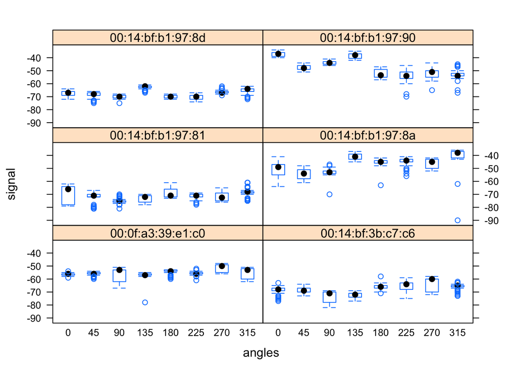

```r
 bwplot(signal ~ factor(angle) | mac, data = offline,
        subset = posX == 2 & posY == 12
        & mac != "00:0f:a3:39:dd:cd", xlab = "angles ",
        layout = c(2,3))
```

```r
 summary(offline$signal)
```

```
##    Min. 1st Qu.  Median    Mean 3rd Qu.    Max.
##  -98.00  -67.00  -59.00  -59.92  -53.00  -25.00
```

#### Signal density at different angels

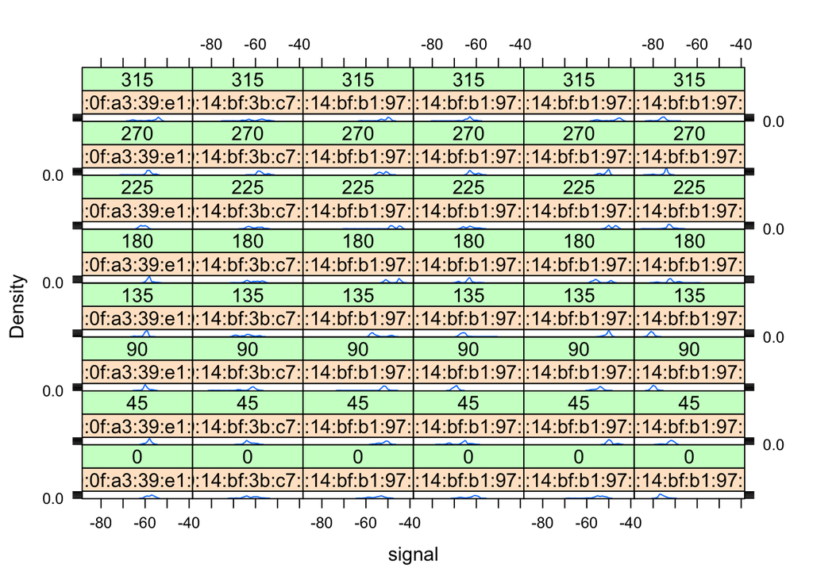

```r
 densityplot( ~ signal | mac + factor(angle), data = offline,
              subset = posX == 24 & posY == 4 &
                mac != "00:0f:a3:39:dd:cd",
              bw = 0.5, plot.points = FALSE)
```

```r
 offline$posXY = paste(offline$posX, offline$posY, sep = "-")
```

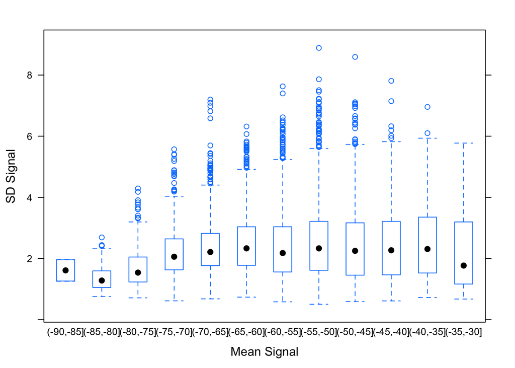

```r
 byLocAngleAP = with(offline,
                     by(offline, list(posXY, angle, mac),
                        function(x) x))
 # Then we can calculate summary statistics on each of these data frames with
 signalSummary =
   lapply(byLocAngleAP,
          function(oneLoc) {
            ans = oneLoc[1, ]
            ans$medSignal = median(oneLoc$signal)
            ans$avgSignal = mean(oneLoc$signal)
            ans$num = length(oneLoc$signal)
            ans$sdSignal = sd(oneLoc$signal)
            ans$iqrSignal = IQR(oneLoc$signal)
            ans
          })
 offlineSummary = do.call("rbind", signalSummary)

 breaks = seq(-90, -30, by = 5)
 aa = bwplot(sdSignal ~ cut(avgSignal, breaks = breaks),
        data = offlineSummary,
        subset = mac != "00:0f:a3:39:dd:cd",
        xlab = "Mean Signal", ylab = "SD Signal")
 print(aa)
```

#### signal strengthe plot for one mac

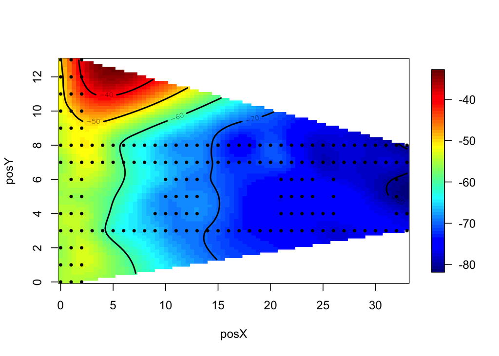

```r
 oneAPAngle = subset(offline, mac == subMacs[5] & angle == 0)

 oneAPAngle = subset(offlineSummary,
                     mac == subMacs[5] & angle == 0)


 smoothSS = Tps(oneAPAngle[, c("posX","posY")],
                oneAPAngle$avgSignal)


 vizSmooth = predictSurface(smoothSS)

 plot.surface(vizSmooth, type = "C")


 points(oneAPAngle$posX, oneAPAngle$posY, pch=19, cex = 0.5)
```

#### a

```r
 surfaceSS(data = offlineSummary, mac == subMacs[5] & angle == 0)
```

[figure not shown]

#### multiple

[figure not shown]

```
## $`00:14:bf:b1:97:90`
## NULL
##
## $`00:14:bf:b1:97:90`
## NULL
##
## $`00:0f:a3:39:e1:c0`
## NULL
##
## $`00:0f:a3:39:e1:c0`
## NULL
```

```r
 parCur = par(mfrow = c(2,2), mar = rep(1, 4))

    mapply(surfaceSS, mac = subMacs[ rep(c(5, 1), each = 2) ],
          angle = rep(c(0, 135), 2),
          data = list(data = offlineSummary))
```

```r
  par(parCur)
```

#### AP

```r
 offlineSummary = subset(offlineSummary, mac != subMacs[2])

  AP = matrix( c( 7.5, 6.3, 2.5, -.8, 12.8, -2.8,
                  1, 14, 33.5, 9.3, 33.5, 2.8),
               ncol = 2, byrow = TRUE,
               dimnames = list(subMacs[ -2 ], c("x", "y") ))

  AP
```

```
##                      x    y
## 00:0f:a3:39:e1:c0  7.5  6.3
## 00:14:bf:b1:97:8a  2.5 -0.8
## 00:14:bf:3b:c7:c6 12.8 -2.8
## 00:14:bf:b1:97:90  1.0 14.0
## 00:14:bf:b1:97:8d 33.5  9.3
## 00:14:bf:b1:97:81 33.5  2.8
```

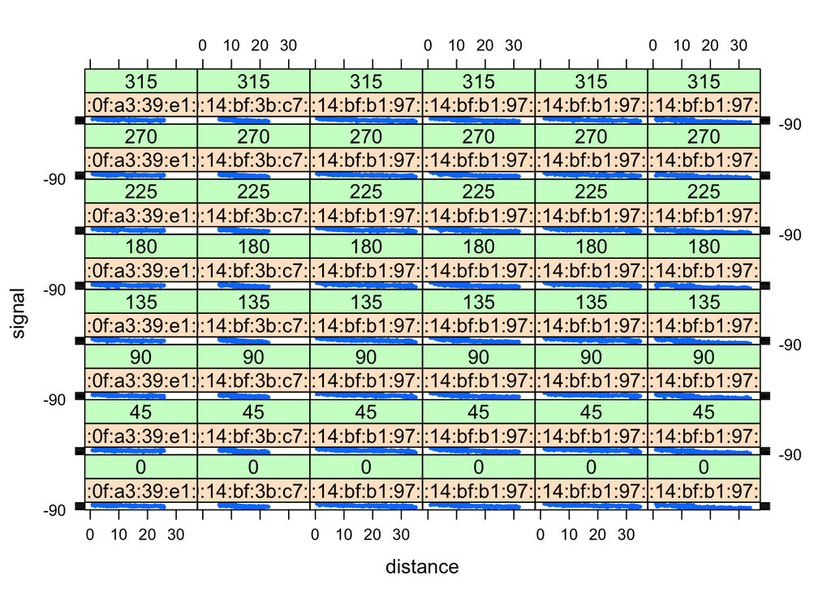

```r
  diffs = offlineSummary[ , c("posX", "posY")] -
    AP[ offlineSummary$mac, ]


  offlineSummary$dist = sqrt(diffs[ , 1]^2 + diffs[ , 2]^2)
  xyplot(signal ~ dist | factor(mac) + factor(angle),
         data = offlineSummary, pch = 19, cex = 0.3,
         xlab ="distance")
```

## Model

### Knn with euclidean distance

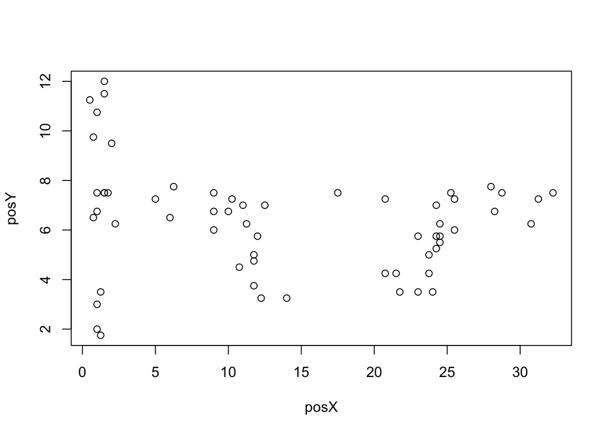

```r
macs = unique(offlineSummary$mac)

 online = readData(online_file_path, subMacs = macs)
 online$posXY = paste(online$posX, online$posY, sep = "-")
 onlineSummary = createOnlineSummary(online)

  actualXY = onlineSummary[ , c("posX", "posY")]
  predicted_locations = predict_online_locations(offlineSummary,onlineSummary)
plot(predicted_locations)
```

```r
  calcError(predicted_locations,actualXY )
```

```
## [1] 301.5728
```

#### without C0

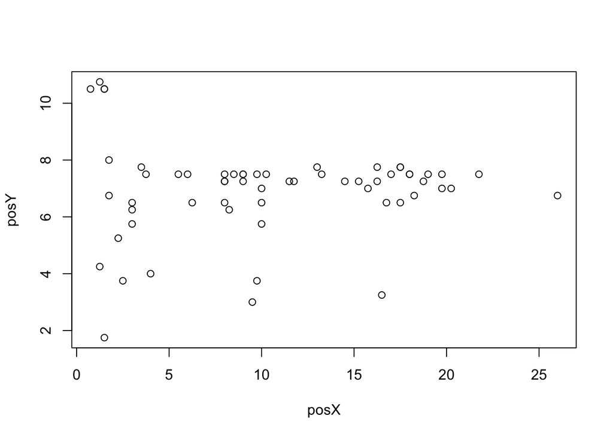

```r
macs = unique(offlineSummary_without_cd$mac)

 online = readData(online_file_path, subMacs = macs)
 online$posXY = paste(online$posX, online$posY, sep = "-")
 onlineSummary = createOnlineSummary(online)

  actualXY = onlineSummary[ , c("posX", "posY")]
  predicted_locations = predict_online_locations(offlineSummary_without_c0,onlineSummary)
plot(predicted_locations)
```

```r
  calcError(predicted_locations,actualXY )
```

```
## [1] 1826.073
```

#### without CD

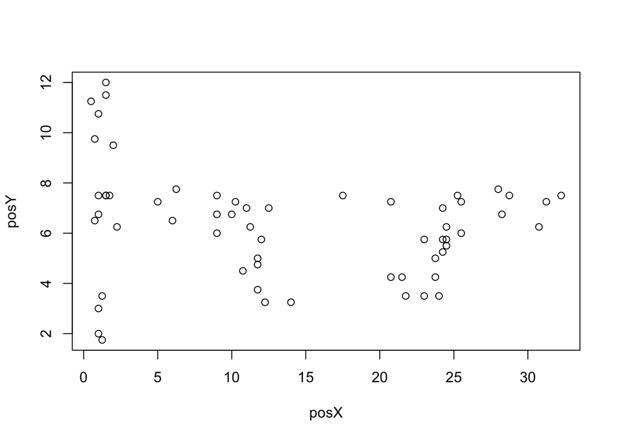

```r
macs = unique(offlineSummary_without_cd$mac)

 online = readData(online_file_path, subMacs = macs)
 online$posXY = paste(online$posX, online$posY, sep = "-")
 onlineSummary = createOnlineSummary(online)

  actualXY = onlineSummary[ , c("posX", "posY")]
  predicted_locations = predict_online_locations(offlineSummary_without_cd, onlineSummary)
plot(predicted_locations)
```

```r
  calcError(predicted_locations,actualXY )
```

```
## [1] 301.5728
```

### Knn with inverse square signal strength (weighted distance formula)

#### without cd

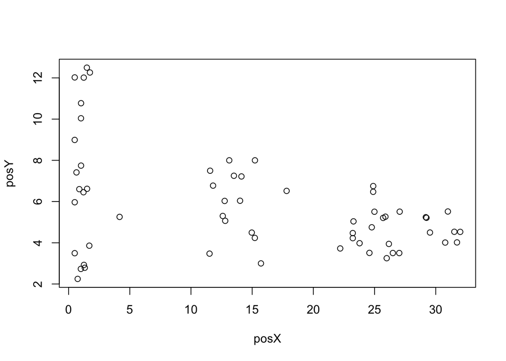

```r
macs = unique(offlineSummary_without_c0$mac)

 online = readData(online_file_path, subMacs = macs)
 online$posXY = paste(online$posX, online$posY, sep = "-")
 onlineSummary = createOnlineSummary(online)
 predicted_locations= predict_online_locations_weighted(offlineSummary_without_cd, onlineSummary)
  plot(predicted_locations)
```

```r
  calcError(predicted_locations,actualXY )
```

```
## [1] 758.6298
```

#### without C0

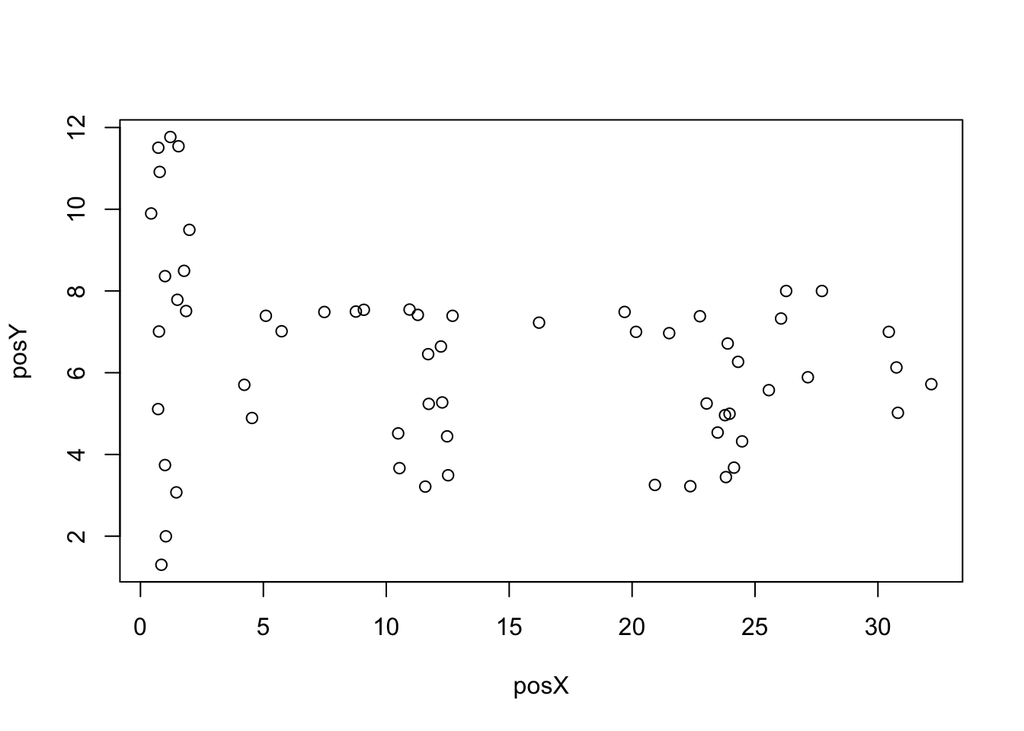

```r
 macs = unique(offlineSummary_without_c0$mac)

 online = readData(online_file_path, subMacs = macs)
 online$posXY = paste(online$posX, online$posY, sep = "-")
 onlineSummary = createOnlineSummary(online)

  actualXY = onlineSummary[ , c("posX", "posY")]
  predicted_locations= predict_online_locations_weighted(offlineSummary_without_c0, onlineSummary)
  plot(predicted_locations)
```

```r
    calcError(predicted_locations,actualXY )
```

```
## [1] 238.5099
```

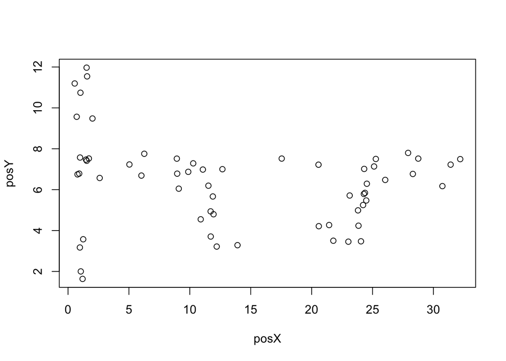

```r
 macs = unique(offlineSummary$mac)

 online = readData(online_file_path, subMacs = macs)
 online$posXY = paste(online$posX, online$posY, sep = "-")
 onlineSummary = createOnlineSummary(online)

  actualXY = onlineSummary[ , c("posX", "posY")]
 predicted_locations= predict_online_locations_weighted(offlineSummary, onlineSummary)
  plot(predicted_locations)
```

```r
  calcError(predicted_locations,actualXY )
```

```
## [1] 297.2603
```

## Example

### cross validation

```r
  k_errors_cd = run_kkross_fold(offlineSummaryData = offlineSummary_without_cd )
  k_errors_c0 = run_kkross_fold(offlineSummaryData = offlineSummary_without_c0 )
```

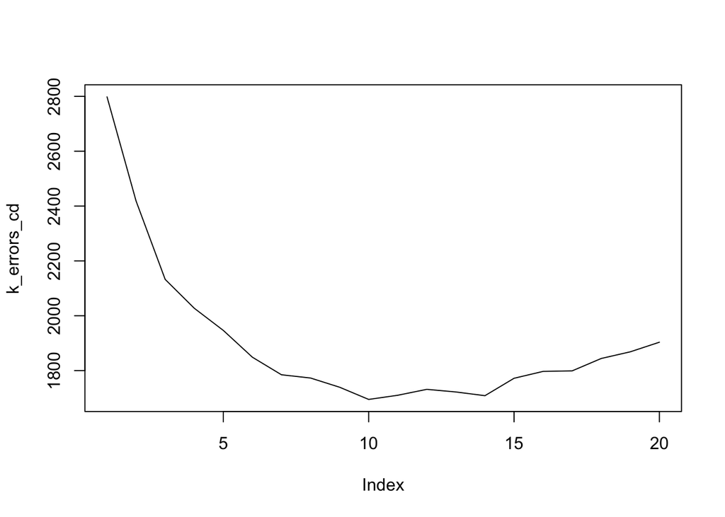

```r
    plot(k_errors_cd, type = 'l')
```

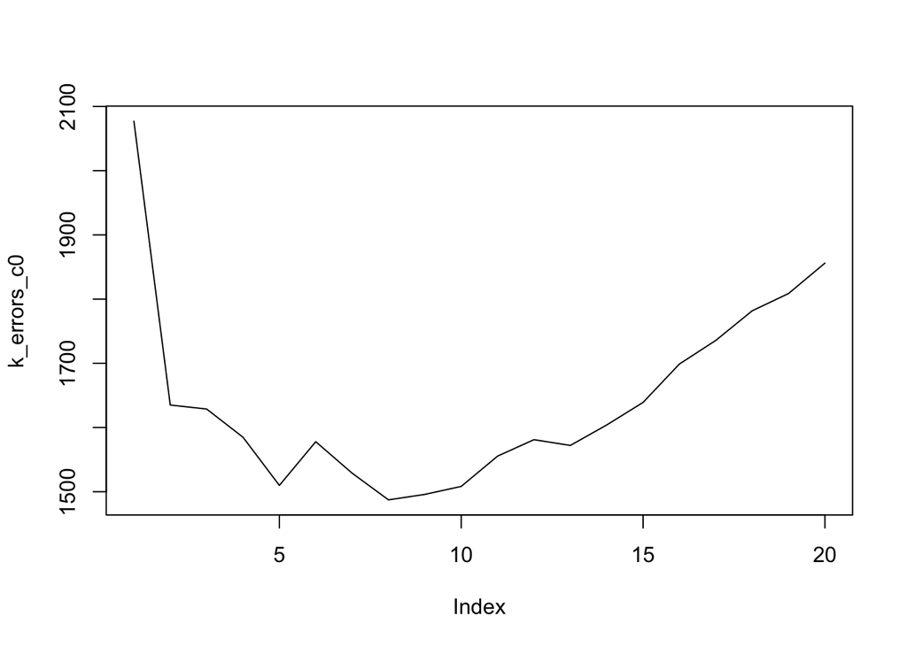

```r
   plot(k_errors_c0, type = 'l')
```